# The National Job Crisis

#### Final Project for Data: A User Manual (CU Denver, Fall 2021)

For months the United States had closed its restaurants, stores, and other businesses following the outbreak of COVID-19. For many businesses it also meant losing valuable employees. With an already crippled labor force, businesses are having a difficult time retaining their workers. The United States Bureau of Labor Statistics (USBLS) recorded unprecedented quit rates across most sectors of the labor market. Why workers are quitting their jobs at an alarming pace remains a topic of debate, and this project will delve deeper into why workers are leaving their jobs even after suffering the hardships brought on by the pandemic. By cross referencing data from the 2007 financial crisis and the COVID-19 pandemic, we can begin to understand why these workers are quitting their jobs.

**Getting started...**

Some of the questions I wanted answers for following this dataset was:

- What is the USBLS? What is their history?
- What job sector(s) are experiencing the highest quit rates?
- What is the average salary of jobs in these sectors?
- When news outlets discuss high quit rates, are they really only talking about specific sectors? Specifically the ones we take most for granted?

# What is the USBLS?

> In 1884, the Bureau of Labor was established in the Department of Interior. In 1888, it became an independent department for nearly 15 years before being incorporated into the Department of Commerce and Labor in 1903. In 1913, the Bureau of Labor Statistics (BLS) was transferred to the newly created Department of Labor. -[USBLS Overview](https://www.bls.gov/bls/history/home.htm)

The USBLS is a fact finding agency in which they compile, analyze, and publish data regarding the job market in the United States. They collect data on job turnover, opportunity, layover, quits, other aspects of the job market that help in understanding the well-being of the US Labor force. Since being established, the USBLS is used by the general public, the federal government, congress, and other public/private entities of the United States. The USBLS states on their website that their main purpose is to state the cold hard facts. They are not looking to humanize the data in any sort of way, even though the labor market is a human entity. They want their data to be objective, relevant, accessible, and timely.

# USBLS Quit Rates

```python
import pandas as pd
```

```python
Q0607_df = pd.read_csv('0607USBLS.csv')
Q2021_df = pd.read_csv('2021USBLS.csv')
R0607_df = pd.read_csv('Rate0607.csv')
R2021_df = pd.read_csv('Rate2021.csv')
Region0607_df = pd.read_csv('0607Region.csv')
Region2021_df = pd.read_csv('2021Region.csv')
USBLS_df = pd.read_csv('QuitTotal.csv')
```

This data all comes from the USBLS website and is accessible to the public. Both of these datasets were not downloadable as a CSV file which required me to transcribe and reformat the data so I could use it in Jupyter. For the 2020/2021 dataset, I was able to copy and paste this dataset into a spreadsheet and reformat it. The 2006/2007 dataset was a lot less friendly to work with. I had to trasncribe it manually onto a spreadsheet and luckily there wasn't so much data that it would have been a daunting task.

```python
Q0607_df = Q0607_df.rename(columns={'Industry and region': 'Industry'})
```

```python
Q0607_df
```

|  | Industry | 2006-09-01 | 2007-04-01 | 2007-05-01 | 2007-06-01 | 2007-07-01 | 2007-08-01 | 2007-09-01 |
| --- | --- | --- | --- | --- | --- | --- | --- | --- |
| 0 | Total | 2566000.0 | 2637000.0 | 2686000.0 | 2627000.0 | 2640000.0 | 2539000.0 | 2640000.0 |
| 1 | NaN | NaN | NaN | NaN | NaN | NaN | NaN | NaN |
| 2 | Total private | 2400000.0 | 2486000.0 | 2530000.0 | 2475000.0 | 2493000.0 | 2391000.0 | 2493000.0 |
| 3 | Mining and logging | NaN | NaN | NaN | NaN | NaN | NaN | NaN |
| 4 | Construction | 135000.0 | 126000.0 | 124000.0 | 129000.0 | 176000.0 | 145000.0 | 176000.0 |
| 5 | Manufacturing | 185000.0 | 199000.0 | 216000.0 | 195000.0 | 186000.0 | 202000.0 | 186000.0 |
| 6 | Durable goods | NaN | NaN | NaN | NaN | NaN | NaN | NaN |
| 7 | Nondurable goods | NaN | NaN | NaN | NaN | NaN | NaN | NaN |
| 8 | Trade, transportation, and utilities | 591000.0 | 600000.0 | 606000.0 | 618000.0 | 572000.0 | 545000.0 | 572000.0 |
| 9 | Wholesale trade | NaN | NaN | NaN | NaN | NaN | NaN | NaN |
| 10 | Retail trade | 430000.0 | 440000.0 | 445000.0 | 448000.0 | 427000.0 | 401000.0 | 427000.0 |
| 11 | Transportation, warehousing, and utilities | NaN | NaN | NaN | NaN | NaN | NaN | NaN |
| 12 | Information | NaN | NaN | NaN | NaN | NaN | NaN | NaN |
| 13 | Financial activities | NaN | NaN | NaN | NaN | NaN | NaN | NaN |
| 14 | Finance and insurance | NaN | NaN | NaN | NaN | NaN | NaN | NaN |
| 15 | Real estate and rental and leasing | NaN | NaN | NaN | NaN | NaN | NaN | NaN |
| 16 | Professional and business services | 443000.0 | 418000.0 | 424000.0 | 411000.0 | 418000.0 | 395000.0 | 418000.0 |
| 17 | Education and health services | 263000.0 | 274000.0 | 284000.0 | 271000.0 | 276000.0 | 270000.0 | 276000.0 |
| 18 | Educational services | NaN | NaN | NaN | NaN | NaN | NaN | NaN |
| 19 | Health care and social assistance | NaN | NaN | NaN | NaN | NaN | NaN | NaN |
| 20 | Leisure and hospitality | 510000.0 | 592000.0 | 551000.0 | 595000.0 | 597000.0 | 557000.0 | 597000.0 |
| 21 | Arts, entertainment, and recreation | NaN | NaN | NaN | NaN | NaN | NaN | NaN |
| 22 | Accommodation and food services | 462000.0 | 542000.0 | 503000.0 | 540000.0 | 552000.0 | 505000.0 | 552000.0 |
| 23 | Other services | NaN | NaN | NaN | NaN | NaN | NaN | NaN |
| 24 | Government | 160000.0 | 153000.0 | 157000.0 | 152000.0 | 148000.0 | 148000.0 | 148000.0 |
| 25 | Federal | NaN | NaN | NaN | NaN | NaN | NaN | NaN |
| 26 | State and local | 125000.0 | 129000.0 | 130000.0 | 123000.0 | 125000.0 | 126000.0 | 125000.0 |
| 27 | State and local education | NaN | NaN | NaN | NaN | NaN | NaN | NaN |
| 28 | State and local, excluding education | NaN | NaN | NaN | NaN | NaN | NaN | NaN |

Interestingly enough, I found that there is an overwhelming amount of job sectors. While there are some of the more self explanatory job sectors like "Construction," there are more obscure job sectors like "Durable goods." Luckily the USBLS has done the homework for us, and we can find each job sectors definition [here](https://www.bls.gov/iag/tgs/iag_index_alpha.htm).

```python
Q2021_df
```

|  | Industry | 2020-08-01 | 2021-04-01 | 2021-05-01 | 2021-06-01 | 2021-07-01 | 2021-08-01 |
| --- | --- | --- | --- | --- | --- | --- | --- |
| 0 | Total | 2987000.0 | 3992000.0 | 3630000.0 | 3870000.0 | 4028000.0 | 4270000.0 |
| 1 | NaN | NaN | NaN | NaN | NaN | NaN | NaN |
| 2 | Total private | 2764000.0 | 3810000.0 | 3470000.0 | 3713000.0 | 3872000.0 | 4096000.0 |
| 3 | Mining and logging | 6000.0 | 11000.0 | 10000.0 | 12000.0 | 9000.0 | 10000.0 |
| 4 | Construction | 95000.0 | 176000.0 | 156000.0 | 185000.0 | 198000.0 | 199000.0 |
| 5 | Manufacturing | 225000.0 | 286000.0 | 245000.0 | 304000.0 | 300000.0 | 306000.0 |
| 6 | Durable goods | 124000.0 | 155000.0 | 120000.0 | 163000.0 | 154000.0 | 166000.0 |
| 7 | Nondurable goods | 101000.0 | 132000.0 | 126000.0 | 141000.0 | 146000.0 | 141000.0 |
| 8 | Trade, transportation, and utilities | 726000.0 | 947000.0 | 851000.0 | 905000.0 | 954000.0 | 1024000.0 |
| 9 | Wholesale trade | 87000.0 | 111000.0 | 90000.0 | 105000.0 | 129000.0 | 155000.0 |
| 10 | Retail trade | 505000.0 | 629000.0 | 596000.0 | 637000.0 | 682000.0 | 721000.0 |
| 11 | Transportation, warehousing, and utilities | 135000.0 | 206000.0 | 166000.0 | 164000.0 | 143000.0 | 148000.0 |
| 12 | Information | 37000.0 | 52000.0 | 45000.0 | 48000.0 | 50000.0 | 44000.0 |
| 13 | Financial activities | 128000.0 | 141000.0 | 121000.0 | 127000.0 | 133000.0 | 119000.0 |
| 14 | Finance and insurance | 102000.0 | 102000.0 | 86000.0 | 78000.0 | 79000.0 | 88000.0 |
| 15 | Real estate and rental and leasing | 26000.0 | 40000.0 | 35000.0 | 49000.0 | 54000.0 | 31000.0 |
| 16 | Professional and business services | 546000.0 | 763000.0 | 614000.0 | 684000.0 | 697000.0 | 706000.0 |
| 17 | Education and health services | 438000.0 | 551000.0 | 523000.0 | 548000.0 | 582000.0 | 579000.0 |
| 18 | Educational services | 34000.0 | 52000.0 | 51000.0 | 46000.0 | 50000.0 | 45000.0 |
| 19 | Health care and social assistance | 404000.0 | 499000.0 | 472000.0 | 502000.0 | 532000.0 | 534000.0 |
| 20 | Leisure and hospitality | 502000.0 | 752000.0 | 762000.0 | 772000.0 | 807000.0 | 971000.0 |
| 21 | Arts, entertainment, and recreation | 11000.0 | 57000.0 | 59000.0 | 66000.0 | 72000.0 | 79000.0 |
| 22 | Accommodation and food services | 491000.0 | 695000.0 | 703000.0 | 706000.0 | 735000.0 | 892000.0 |
| 23 | Other services | 61000.0 | 131000.0 | 143000.0 | 128000.0 | 142000.0 | 136000.0 |
| 24 | Government | 223000.0 | 182000.0 | 160000.0 | 156000.0 | 157000.0 | 175000.0 |
| 25 | Federal | 20000.0 | 18000.0 | 22000.0 | 25000.0 | 19000.0 | 19000.0 |
| 26 | State and local | 203000.0 | 165000.0 | 138000.0 | 131000.0 | 137000.0 | 156000.0 |
| 27 | State and local education | 128000.0 | 84000.0 | 64000.0 | 34000.0 | 45000.0 | 70000.0 |
| 28 | State and local, excluding education | 75000.0 | 81000.0 | 74000.0 | 97000.0 | 92000.0 | 86000.0 |

# Let's Compare

```python
total_df = USBLS_df.rename(columns={'Unnamed: 0': 'Industry'})
total_df
```

|  | Industry | 06/07 | 20/21 |
| --- | --- | --- | --- |
| 0 | Total | 18335000.0 | 22777000.0 |
| 1 | NaN | NaN | NaN |
| 2 | Total private | 17268000.0 | 21725000.0 |
| 3 | Mining and logging | 0.0 | 58000.0 |
| 4 | Construction | 1011000.0 | 1009000.0 |
| 5 | Manufacturing | 1369000.0 | 1666000.0 |
| 6 | Durable goods | 0.0 | 882000.0 |
| 7 | Nondurable goods | 0.0 | 787000.0 |
| 8 | Trade, transportation, and utilities | 4104000.0 | 5407000.0 |
| 9 | Wholesale trade | 0.0 | 677000.0 |
| 10 | Retail trade | 3018000.0 | 3770000.0 |
| 11 | Transportation, warehousing, and utilities | 0.0 | 962000.0 |
| 12 | Information | 0.0 | 276000.0 |
| 13 | Financial activities | 0.0 | 769000.0 |
| 14 | Finance and insurance | 0.0 | 535000.0 |
| 15 | Real estate and rental and leasing | 0.0 | 235000.0 |
| 16 | Professional and business services | 2927000.0 | 4010000.0 |
| 17 | Education and health services | 1914000.0 | 3221000.0 |
| 18 | Educational services | 0.0 | 278000.0 |
| 19 | Health care and social assistance | 0.0 | 2943000.0 |
| 20 | Leisure and hospitality | 3999000.0 | 4566000.0 |
| 21 | Arts, entertainment, and recreation | 0.0 | 344000.0 |
| 22 | Accommodation and food services | 3656000.0 | 4222000.0 |
| 23 | Other services | 0.0 | 741000.0 |
| 24 | Government | 1066000.0 | 1053000.0 |
| 25 | Federal | 0.0 | 123000.0 |
| 26 | State and local | 883000.0 | 930000.0 |
| 27 | State and local education | 0.0 | 425000.0 |
| 28 | State and local, excluding education | 0.0 | 505000.0 |

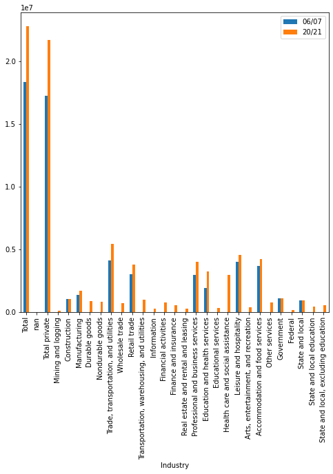

```python
total_df.plot.bar('Industry', figsize = (8,8))
```

The y-axis is quit number in millions, I just couldn't figure out how to name it in code.

```python
R0607_df = R0607_df.rename(columns={'Industry and region': 'Industry'})
```

```python
R0607_df
```

|  | Industry | 2006-09-01 | 2007-04-01 | 2007-05-01 | 2007-06-01 | 2007-07-01 | 2007-08-01 | 2007-09-01 |
| --- | --- | --- | --- | --- | --- | --- | --- | --- |
| 0 | Total | 1.9 | 1.9 | 1.9 | 1.9 | 1.9 | 1.8 | 1.8 |
| 1 | NaN | NaN | NaN | NaN | NaN | NaN | NaN | NaN |
| 2 | Total private | 2.1 | 2.2 | 2.2 | 2.1 | 2.2 | 2.1 | 2.0 |
| 3 | Mining and logging | NaN | NaN | NaN | NaN | NaN | NaN | NaN |
| 4 | Construction | 1.7 | 1.6 | 1.6 | 1.7 | 2.3 | 1.9 | 1.8 |
| 5 | Manufacturing | 1.3 | 1.4 | 1.5 | 1.4 | 1.3 | 1.4 | 1.3 |
| 6 | Durable goods | NaN | NaN | NaN | NaN | NaN | NaN | NaN |
| 7 | Nondurable goods | NaN | NaN | NaN | NaN | NaN | NaN | NaN |
| 8 | Trade, transportation, and utilities | 2.3 | 2.3 | 2.3 | 2.3 | 2.2 | 2.1 | 2.0 |
| 9 | Wholesale trade | NaN | NaN | NaN | NaN | NaN | NaN | NaN |
| 10 | Retail trade | 2.8 | 2.9 | 2.9 | 2.9 | 2.8 | 2.6 | 2.6 |
| 11 | Transportation, warehousing, and utilities | NaN | NaN | NaN | NaN | NaN | NaN | NaN |
| 12 | Information | NaN | NaN | NaN | NaN | NaN | NaN | NaN |
| 13 | Financial activities | NaN | NaN | NaN | NaN | NaN | NaN | NaN |
| 14 | Finance and insurance | NaN | NaN | NaN | NaN | NaN | NaN | NaN |
| 15 | Real estate and rental and leasing | NaN | NaN | NaN | NaN | NaN | NaN | NaN |
| 16 | Professional and business services | 2.5 | 2.3 | 2.4 | 2.3 | 2.3 | 2.2 | 2.3 |
| 17 | Education and health services | 1.5 | 1.5 | 1.6 | 1.5 | 1.5 | 1.5 | 1.3 |
| 18 | Educational services | NaN | NaN | NaN | NaN | NaN | NaN | NaN |
| 19 | Health care and social assistance | NaN | NaN | NaN | NaN | NaN | NaN | NaN |
| 20 | Leisure and hospitality | 3.9 | 4.4 | 4.1 | 4.4 | 4.4 | 4.1 | 3.4 |
| 21 | Arts, entertainment, and recreation | NaN | NaN | NaN | NaN | NaN | NaN | NaN |
| 22 | Accommodation and food services | 4.1 | 4.7 | 4.3 | 4.7 | 4.8 | 4.4 | 3.5 |
| 23 | Other services | NaN | NaN | NaN | NaN | NaN | NaN | NaN |
| 24 | Government | 0.7 | 0.7 | 0.7 | 0.7 | 0.7 | 0.7 | 0.7 |
| 25 | Federal | NaN | NaN | NaN | NaN | NaN | NaN | NaN |
| 26 | State and local | 0.6 | 0.7 | 0.7 | 0.6 | 0.6 | 0.6 | 0.6 |
| 27 | State and local education | NaN | NaN | NaN | NaN | NaN | NaN | NaN |
| 28 | State and local, excluding education | NaN | NaN | NaN | NaN | NaN | NaN | NaN |

```python
R0607_df.max()
```

```
2006-09-01    4.1
2007-04-01    4.7
2007-05-01    4.3
2007-06-01    4.7
2007-07-01    4.8
2007-08-01    4.4
2007-09-01    3.5
dtype: float64
```

When I displayed the maximum quit rates, I was surprised to find that these all fall under the occupation of accomodation and foods services. If we go back to the hyperlink above, we can find that accomodation and foods and services is defined as "establishments providing customers with lodging and/or preparing meals, snacks, and beverages for immediate consumption. The sector includes both accommodation and food services establishments because the two activities are often combined at the same establishment."

Let's move on to the quit rates of 2020/2021...

```python
R2021_df = R2021_df.rename(columns={'Industry and region': 'Industry'})
```

```python
R2021_df
```

|  | Industry | 2020-08-01 | 2021-04-01 | 2021-05-01 | 2021-06-01 | 2021-07-01 | 2021-08-01 |
| --- | --- | --- | --- | --- | --- | --- | --- |
| 0 | Total | 2.1 | 2.8 | 2.5 | 2.7 | 2.7 | 2.9 |
| 1 | NaN | NaN | NaN | NaN | NaN | NaN | NaN |
| 2 | Total private | 2.3 | 3.1 | 2.8 | 3.0 | 3.1 | 3.3 |
| 3 | Mining and logging | 1.1 | 1.9 | 1.7 | 1.9 | 1.5 | 1.6 |
| 4 | Construction | 1.3 | 2.4 | 2.1 | 2.5 | 2.7 | 2.7 |
| 5 | Manufacturing | 1.9 | 2.3 | 2.0 | 2.5 | 2.4 | 2.5 |
| 6 | Durable goods | 1.7 | 2.0 | 1.6 | 2.1 | 2.0 | 2.1 |
| 7 | Nondurable goods | 2.2 | 2.8 | 2.7 | 3.0 | 3.1 | 3.0 |
| 8 | Trade, transportation, and utilities | 2.7 | 3.5 | 3.1 | 3.3 | 3.5 | 3.7 |
| 9 | Wholesale trade | 1.6 | 2.0 | 1.6 | 1.8 | 2.3 | 2.7 |
| 10 | Retail trade | 3.4 | 4.1 | 3.9 | 4.2 | 4.4 | 4.7 |
| 11 | Transportation, warehousing, and utilities | 2.2 | 3.3 | 2.6 | 2.6 | 2.3 | 2.3 |
| 12 | Information | 1.4 | 1.9 | 1.6 | 1.8 | 1.8 | 1.6 |
| 13 | Financial activities | 1.5 | 1.6 | 1.4 | 1.4 | 1.5 | 1.3 |
| 14 | Finance and insurance | 1.6 | 1.6 | 1.3 | 1.2 | 1.2 | 1.3 |
| 15 | Real estate and rental and leasing | 1.2 | 1.8 | 1.6 | 2.2 | 2.4 | 1.3 |
| 16 | Professional and business services | 2.7 | 3.7 | 3.0 | 3.3 | 3.3 | 3.4 |
| 17 | Education and health services | 1.9 | 2.4 | 2.2 | 2.3 | 2.5 | 2.4 |
| 18 | Educational services | 1.0 | 1.5 | 1.5 | 1.3 | 1.4 | 1.2 |
| 19 | Health care and social assistance | 2.1 | 2.5 | 2.4 | 2.5 | 2.7 | 2.7 |
| 20 | Leisure and hospitality | 3.9 | 5.3 | 5.3 | 5.2 | 5.3 | 6.4 |
| 21 | Arts, entertainment, and recreation | 0.7 | 3.0 | 3.0 | 3.2 | 3.4 | 3.7 |
| 22 | Accommodation and food services | 4.3 | 5.7 | 5.7 | 5.5 | 5.6 | 6.8 |
| 23 | Other services | 1.1 | 2.3 | 2.6 | 2.3 | 2.5 | 2.4 |
| 24 | Government | 1.0 | 0.8 | 0.7 | 0.7 | 0.7 | 0.8 |
| 25 | Federal | 0.6 | 0.6 | 0.8 | 0.9 | 0.7 | 0.7 |
| 26 | State and local | 1.1 | 0.9 | 0.7 | 0.7 | 0.7 | 0.8 |
| 27 | State and local education | 1.3 | 0.9 | 0.7 | 0.3 | 0.4 | 0.7 |
| 28 | State and local, excluding education | 0.8 | 0.9 | 0.8 | 1.1 | 1.0 | 1.0 |

```python
R2021_df.max()
```

```
2020-08-01    4.3
2021-04-01    5.7
2021-05-01    5.7
2021-06-01    5.5
2021-07-01    5.6
2021-08-01    6.8
dtype: float64
```

Again, we experience the same case. It seems as though Accomodation and Food Services takes the heaviest tolls following national financial crises. As I explored this dataset I noticed a trend in quit rates for "low skill" jobs, a term the US often associates with jobs in these sectors. Are the rising quit rates a product of national financial struggle, or is this a reflection of the financial workings in this country? This encouraged me to delve into more qualitative research, and NPR had some useful interviews and articles.

As the pandemic recedes (if you could even say that), people are fed up with insufficient wages combined with rising costs of living. Workers in food services, hotel, and other accomodations are searching for jobs with higher wages, better benefits, and more flexible hours. The pandemic has not made living easier for any of us, but to assume that the pandemic is the main reason people are leaving their jobs seems to be naive.

> More than 740,000 people who quit in April worked in the leisure and hospitality industry, which includes jobs in hotels, bars and restaurants, theme parks and other entertainment venues. Jeremy Golembiewski has ideas about why. Last week, after 26 years in food service, he quit his job as general manager of a breakfast place in San Diego... With enough savings to last a month or two, he's sharpening his resume, working on his typing skills and starting to interview for jobs in fields that are new to him: retail, insurance, data entry. The one thing he's sure of: He wants to work a 40-hour week. [As The Pandemic Recedes, Millions Of Workers Are Saying 'I Quit'](https://www.npr.org/2021/06/24/1007914455/as-the-pandemic-recedes-millions-of-workers-are-saying-i-quit)

An inadequate wage is exacerbated when the cost of living continues to rise at an unsustainable rate as well.

> Facing a new surge of visitors, food establishments are hiring like crazy but still, many have had to operate with skeleton crews and even reduce their hours. "We used to be known as a late-night restaurant. ... We can't do that anymore. I don't have the staff and people are exhausted," said Laurie Torres, whose Ohio restaurant now closes earlier and stays closed on Mondays. She said she's been paying her staff bonuses and offered $17 an hour for a dishwasher job, and even then three workers stood her up. In fact, for the first time on record, average hourly pay for nonmanagers at restaurants and bars topped $15 in May. [Low Pay, No Benefits, Rude Customers: Restaurant Workers Quit At Record Rate](https://www.npr.org/2021/07/20/1016081936/low-pay-no-benefits-rude-customers-restaurant-workers-quit-at-record-rate)

While some of us may see \$15-\\$17 an hour as tempting wage, we can not forget that this is still an insufficient wage to be able to live comfortably. The National Low Income Housing Coalition found in its latest Out of Reach report that "a renter in search of a modest two-bedroom home, who is seeking to stay within the 30% income window, needs to earn \$24.90 per hour... Those in search of a one-bedroom are in a similar position; they need to make \\$20.40 per hour." A wage of \$24.90 per hour is 3.4 times higher than the federal minimum wage.

```python
Region0607_df = Region0607_df.rename(columns={'REGION(3)': 'Region'})
```

```python
Region0607_df
```

|  | Region | 2006-09-01 | 2007-04-01 | 2007-05-01 | 2007-06-01 | 2007-07-01 | 2007-08-01 | 2007-09-01 |
| --- | --- | --- | --- | --- | --- | --- | --- | --- |
| 0 | Northeast | 383000 | 350000 | 331000 | 380000 | 314000 | 313000 | 316000 |
| 1 | South | 1102000 | 1163000 | 1162000 | 1049000 | 1097000 | 1070000 | 995000 |
| 2 | Midwest | 541000 | 544000 | 551000 | 555000 | 553000 | 564000 | 541000 |
| 3 | West | 551000 | 590000 | 643000 | 648000 | 669000 | 598000 | 577000 |

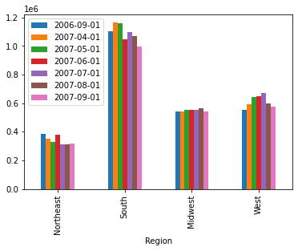

```python
Region0607_df.plot.bar('Region')
```

```python
Region2021_df = Region2021_df.rename(columns={'REGION(3)': 'Region'})
```

```python
Region2021_df
```

|  | Region | 2020-08-01 | 2021-04-01 | 2021-05-01 | 2021-06-01 | 2021-07-01 | 2021-08-01 |
| --- | --- | --- | --- | --- | --- | --- | --- |
| 0 | Northeast | 441000 | 458000 | 531000 | 589000 | 619000 | 603000 |
| 1 | South | 1426000 | 1487000 | 1561000 | 1596000 | 1706000 | 1793000 |
| 2 | Midwest | 723000 | 827000 | 889000 | 921000 | 1024000 | 955000 |
| 3 | West | 718000 | 858000 | 888000 | 921000 | 921000 | 1083000 |

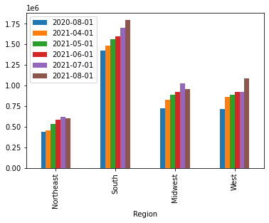

```python
Region2021_df.plot.bar('Region')
```

If we look below at the minimum wage chart and cross reference it with the regional quit rates, it is quite telling to see how high quit rates are in the South. If they're maintaining a minimum wage of $7.25 per hour, then it wouldn't be unreasonable to say that people are leaving because of inadequate wages. On the other end of the spectrum, the northeastern portion of the United States has the lowest quit rates, while also having the highest minimum wages.

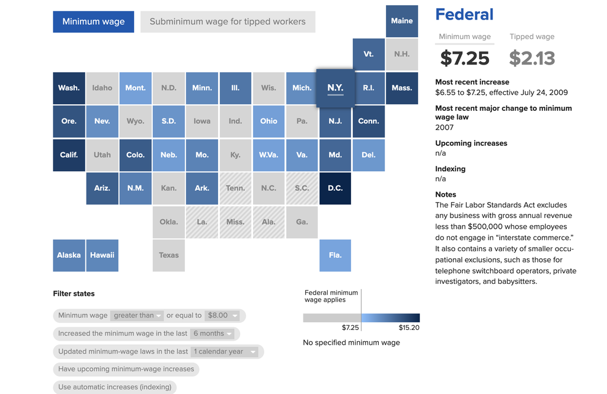

# So What...

Figuring out why 4.4 million American's quit their job in Septemeber alone can be a daunting endeavouor. We often associate those that quit their jobs as being lazy or being quitters and [Forbes](https://www.forbes.com/sites/jackkelly/2021/11/15/weve-become-a-nation-of-quitters-44-million-americans-left-their-jobs-in-september/?sh=13bb3a31893e) isn't helping anyone either in the way they frame America's Great Resignation. Simply put, the COVID-19 pandemic has only exacerbated pre-exisiting issues in our labor force and our economy. Workers are beginning to see that wages are not moving with rising inflation, their benefits aren't coming, and their conditions aren't improving. Consequently, workers are up and leaving to either find new opportunities or simply leave their less than satisfactory jobs. While the Financial Crisis and the COVID-19 Pandemic made life a lot more difficult for American laborers, we are now in a time where wages are substantially more disproportionate to the cost of living.